# Untitled

Ruben Sanchez Ramirez

5/17/2021

```r
# Attach packages:
library(tidyverse)
library(sensitivity)
library(ggplot2)
```

Rabbits and Hawks Population Matrix Assignment

A small city with a large urban park has decided to introduce a rare species of rabbits into this park - Rabbits are cute and the kids love them, and giving a rare species a new home sounds like a good idea. The urban park manager is concerned about how this rabbit population might grow over the next few decades. Rabbits have no natural predators in the region where the park is situated. The manager would like to know, approximately, how many rabbits there will be 20 years from now if the rabbits are introduced as planned. The manager reviewed the literature and found the following estimates for survival and fertility rates for the rare rabbit population, for 4 different age classes. The estimates for these rates are shown below

Fertility (rabbit/female) - Survivability

Young (Age 0-1) - 0 - 0.8 Sub-Adults (Age 1-2) - 2 - 0.85 Adult (Age 2-3) - 6 - 0.65 Aged (Age 3-4) - 1 - 0.1

Using a matrix population model approach answer the following questions for the manager: Assume that we start with 10 adults rabbits. What is the total rabbit population after 20 years. How many young rabbits (first age class) are there in the population at that time?

```r
nclasses = 4

# create a growth matrix to store fertility and survivability information
gmatrix=matrix(nrow=nclasses, ncol=nclasses)

# change NAs to zero
gmatrix[]=0.0

# assign values for fertility for each of the age classes
# notes that fertility rates are births per capita (number in class) per
# time step - time step here is years
fert =  c(0,2,6,1)

# enter into our matrix
gmatrix[1,]=fert

# now add survivability
# survivability (to the next class) is also per time step
gmatrix[2,1]=0.8
gmatrix[3,2]=0.85
gmatrix[4,3]=0.65

# we als want to to account for the oldest population group - they don't transfer to another group
# but they do die - this will be survivability per time step but they just stay in their class/group
gmatrix[4,4]=0.1
gmatrix
```

```
##      [,1] [,2] [,3] [,4]
## [1,]  0.0 2.00 6.00  1.0
## [2,]  0.8 0.00 0.00  0.0
## [3,]  0.0 0.85 0.00  0.0
## [4,]  0.0 0.00 0.65  0.1
```

```r
source("./evolve_pop.R")

# initial population parameters
ini = c(0,0,10,0)
nyears = 20
fert_rabbit = c(0,2,6,1)
surv_rabbit = c(0.8,0.85,0.65,0.1)
rabbit_pop=evolve_pop(fert_rabbit, surv_rabbit, ini, nyears)

tail(rabbit_pop)
```

```
## $popbyage
##      [,1] [,2]  [,3]   [,4]     [,5]      [,6]      [,7]      [,8]      [,9]
## [1,]    0 60.0  6.50 96.650 255.2650 207.68650 808.28165 1417.0515 2257.7659
## [2,]    0  0.0 48.00  5.200  77.3200 204.21200 166.14920  646.6253 1133.6412
## [3,]   10  0.0  0.00 40.800   4.4200  65.72200 173.58020  141.2268  549.6315
## [4,]    0  6.5  0.65  0.065  26.5265   5.52565  43.27187  117.1543  103.5129
##          [,10]     [,11]     [,12]     [,13]     [,14]      [,15]     [,16]
## [1,] 5668.5843 9761.6072 18944.518 39810.638 72750.524 145566.477 287659.30
## [2,] 1806.2127 4534.8675  7809.286 15155.614 31848.510  58200.419 116453.18
## [3,]  963.5950 1535.2808  3854.637  6637.893 12882.272  27071.234  49470.36
## [4,]  367.6118  663.0979  1064.242  2611.939  4575.824   8831.059  18479.41
##          [,17]      [,18]     [,19]     [,20]
## [1,] 548207.91 1088169.78 2118523.3 4111679.4
## [2,] 230127.44  438566.33  870535.8 1694818.7
## [3,]  98985.20  195608.32  372781.4  739955.4
## [4,]  34003.67   67740.75  133919.5  255699.8
##
## $poptot
##  [1]       0.0000      10.0000      66.5000      55.1500     142.7150
##  [6]     363.5315     483.1462    1191.2829    2322.0579    4044.5514
## [11]    8806.0038   16494.8533   31672.6830   64216.0834  122057.1304
## [16]  239669.1889  472062.2456  911324.2250 1790085.1785 3495760.0330
```

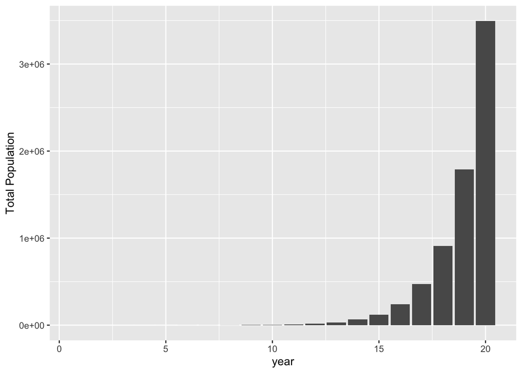

```r
# graph differnt components of the output
# total population

# add year
year = seq(from=1, to=nyears)
rabbit_tot = cbind.data.frame(year=year, poptot=rabbit_pop$poptot)
ggplot(rabbit_tot, aes(year, poptot))+geom_col()+labs(y="Total Population")
```

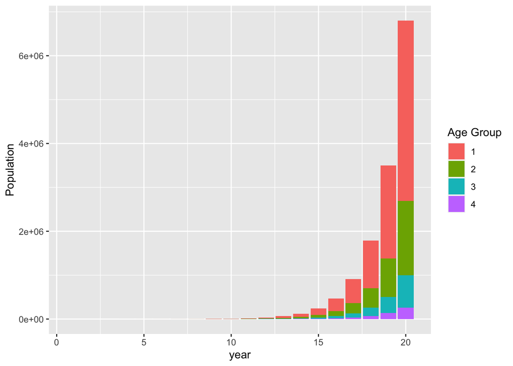

```r
# plot information about ages
rabbit_ages = cbind.data.frame(year=year, t(rabbit_pop$popbyage))
rabbit_agesl = rabbit_ages %>% gather(key="agecat", value="pop",-year)
ggplot(rabbit_agesl, aes(year, pop, fill=agecat))+geom_col()+labs(y="Population", fill="Age Group")
```

```r
library(sensitivity)

# survivability - based on mortality rates per thousand per decade
nsample=200

# create our two samples for Sobel
# first do our survivability
ps1 = cbind.data.frame(p1=runif(min=0.65, max=0.75, n=nsample),
                       p2 = runif(min=0.75, max=0.80, n=nsample),
                       p3 = rep(0.65, n=nsample),
                       p4 = rep(0.1, n=nsample))

ps2 = cbind.data.frame(p1=runif(min=0.65, max=0.75, n=nsample),
                       p2 = runif(min=0.75, max=0.80, n=nsample),
                       p3 = rep(0.65, n=nsample),
                       p4 = rep(0.1, n=nsample))

# get sobel samples
sens_rabbit=soboljansen(model = NULL, ps1, ps2, nboot = 100)

head(sens_rabbit$X)
```

```
##          p1        p2   p3  p4
## 1 0.7290634 0.7963714 0.65 0.1
## 2 0.7357916 0.7736955 0.65 0.1
## 3 0.6844269 0.7798370 0.65 0.1
## 4 0.7443337 0.7574593 0.65 0.1
## 5 0.7277193 0.7751260 0.65 0.1
## 6 0.7280779 0.7838152 0.65 0.1
```

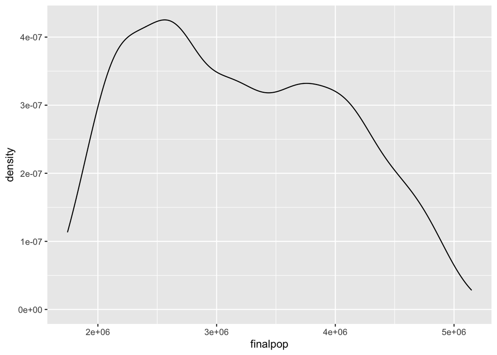

```r
nsim=nrow(sens_rabbit$X)

# Survivability
#p3 = 0.65
#p4 = 0.1

# Fertility
f1 = 0
f2 = 2
f3 = 6
f4 = 1

# run model and save what we care about: final population after 12 months
# this is already output by evolve_pop so we don't need a compute_metric function

ini = c(0,0,10,0)
nyears = 20


# as before combine our application of the the dynamics model - for each
# parameter set, with code to extract our metric of interest (final population)
p_wrapper = function(p1,p2,p3,p4,f1,f2,f3,f4,
                     use_func,initialpop,nstep ) {
fertility=c(f1,f2,f3,f3)
survivability= c(p1,p2,p3,p4)
res = use_func(survivability =survivability, fertility = fertility, initialpop=initialpop, nstep=nstep)
# now return the final population total
return(finalpop=res$poptot[nstep])
}


# use pmap here so we can specify rows of our sensitivity analysis parameter object
res = as.data.frame(sens_rabbit$X) %>% pmap_dbl(p_wrapper, initialpop=ini, nstep=nyears, use_func=evolve_pop,f1=f1,f2=f2,f3=f3)

# plot results (variation in final population across all parameter)
# ggplot needs a dataframe - so do a quick conversion with data.frame
ggplot(data.frame(finalpop=res), aes(x=finalpop))+geom_density()
```

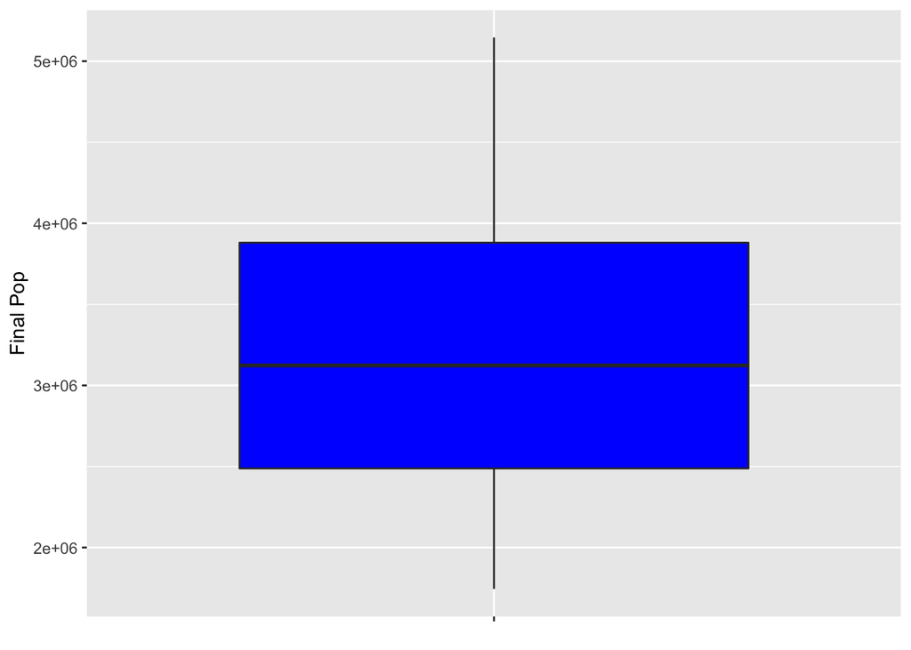

```r
# or a boxplot
ggplot(data.frame(finalpop=res), aes(x="", y=finalpop) )+geom_boxplot(fill="blue")+
  theme(axis.title.x = element_blank())+labs(y="Final Pop")
```

```r
# give our results to sensitivity structure

sens_rabbit=tell(sens_rabbit, res)

# loot at results
sens_rabbit$S
```

```
##       original          bias  std. error   min. c.i. max. c.i.
## p1  0.92552709 -0.0008330481 0.007354559  0.91245014 0.9406041
## p2  0.09912399  0.0047550961 0.082652490 -0.05361663 0.2754981
## p3 -0.03420080  0.0029390637 0.082423729 -0.18252378 0.1201853
## p4 -0.03420080  0.0029390637 0.082423729 -0.18252378 0.1201853
```

```r
sens_rabbit$T
```

```
##      original          bias  std. error  min. c.i.  max. c.i.
## p1 0.88732068 -0.0045367643 0.080502433 0.71831459 1.04230172
## p2 0.08228476  0.0006097553 0.008135814 0.06889016 0.09784932
## p3 0.00000000  0.0000000000 0.000000000 0.00000000 0.00000000
## p4 0.00000000  0.0000000000 0.000000000 0.00000000 0.00000000
```

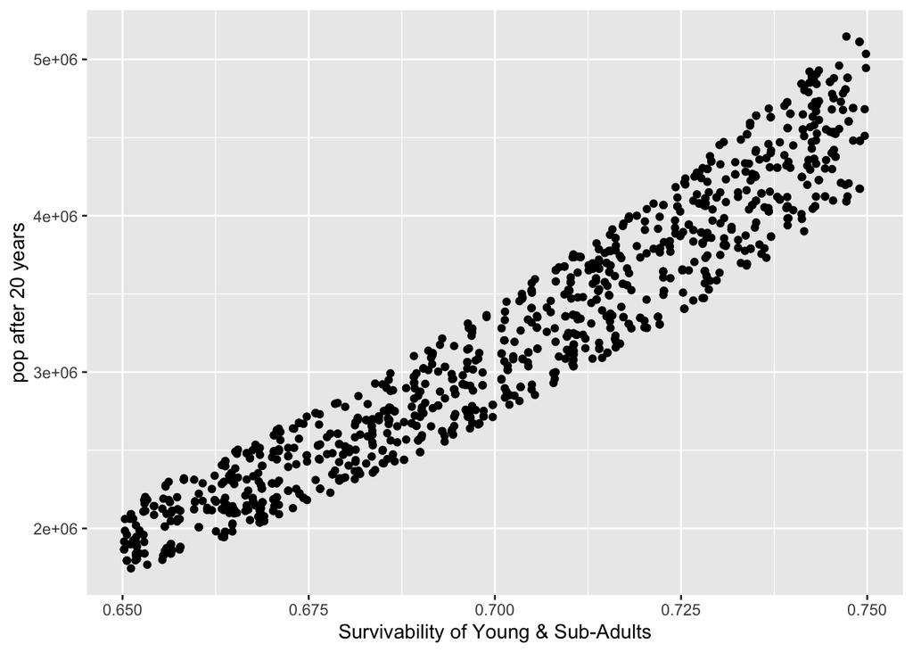

```r
# graph the most sensitive parameter
tmp = cbind.data.frame(sens_rabbit$X, pop1=sens_rabbit$y)
ggplot(tmp, aes(p1, pop1))+geom_point()+labs(x="Survivability of Young & Sub-Adults",y="pop after 20 years")
```